# Analyzing the NYPD shooting incident data set

Jin Shi

2/13/2022

## Load Data and data clean

```r
NYPDdata = read.csv('https://data.cityofnewyork.us/api/views/833y-fsy8/rows.csv?accessType=DOWNLOAD')
```

The data comes from a file called NYPD Shooting Incident Data (Historic) on the https://catalog.data.gov/dataset.

Dropping additional variables which aren’t used for visualizations or analyses.

```r
NYPDdata= select (NYPDdata, -c(INCIDENT_KEY,X_COORD_CD,Y_COORD_CD,Latitude,Longitude,Lon_Lat))
NYPDdata = as.data.frame(unclass(NYPDdata),stringsAsFactors = TRUE)
summary(NYPDdata)
```

```
##       OCCUR_DATE       OCCUR_TIME               BORO         PRECINCT
##  07/05/2020:   47   23:30:00:  159   BRONX        :6701   Min.   :  1.00
##  09/04/2011:   31   01:30:00:  141   BROOKLYN     :9734   1st Qu.: 44.00
##  07/26/2020:   29   00:30:00:  136   MANHATTAN    :2922   Median : 69.00
##  08/11/2007:   26   02:00:00:  129   QUEENS       :3532   Mean   : 66.21
##  09/04/2006:   25   21:00:00:  128   STATEN ISLAND: 696   3rd Qu.: 81.00
##  08/15/2020:   24   22:30:00:  126                        Max.   :123.00
##  (Other)   :23403   (Other) :22766
##  JURISDICTION_CODE                   LOCATION_DESC   STATISTICAL_MURDER_FLAG
##  Min.   :0.000                              :13581   false:19085
##  1st Qu.:0.000     MULTI DWELL - PUBLIC HOUS: 4240   true : 4500
##  Median :0.000     MULTI DWELL - APT BUILD  : 2553
##  Mean   :0.333     PVT HOUSE                :  857
##  3rd Qu.:0.000     GROCERY/BODEGA           :  574
##  Max.   :2.000     BAR/NIGHT CLUB           :  562
##  NA's   :2         (Other)                  : 1218
##  PERP_AGE_GROUP PERP_SEX           PERP_RACE     VIC_AGE_GROUP   VIC_SEX
##         :8295    : 8261   BLACK         :10025   <18    : 2525   F: 2204
##  18-24  :5508   F:  335                 : 8261   18-24  : 9003   M:21370
##  25-44  :4714   M:13490   WHITE HISPANIC: 1988   25-44  :10303   U:   11
##  UNKNOWN:3148   U: 1499   UNKNOWN       : 1836   45-64  : 1541
##  <18    :1368             BLACK HISPANIC: 1096   65+    :  154
##  45-64  : 495             WHITE         :  255   UNKNOWN:   59
##  (Other):  57             (Other)       :  124
##                            VIC_RACE
##  AMERICAN INDIAN/ALASKAN NATIVE:    9
##  ASIAN / PACIFIC ISLANDER      :  327
##  BLACK                         :16869
##  BLACK HISPANIC                : 2245
##  UNKNOWN                       :   65
##  WHITE                         :  620
##  WHITE HISPANIC                : 3450
```

## Analysis

### The area where the incident occurred

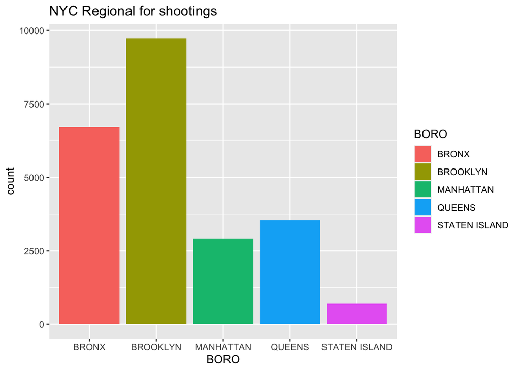

```r
ggplot(NYPDdata,aes(BORO)) + geom_bar(aes(fill=BORO)) + labs(title = "NYC Regional for shootings")
```

```r
summary(NYPDdata$BORO)
```

```
##         BRONX      BROOKLYN     MANHATTAN        QUEENS STATEN ISLAND
##          6701          9734          2922          3532           696
```

####we can see the shooting rates in the New York City Borough####

| BRONX | BROOKLYN | MANHTTAN | QUEENS | STATEN ISLAND |
| --- | --- | --- | --- | --- |
| 28.41% | 41.27% | 12.39% | 14.98% | 2.95% |

summary：We can see the overall regional distribution of shootings in the histogram above. As you can see from the histogram, BROOKLYN has the highest incidence of shootings in New York City, while STATEN ISLAND has the lowest incidence of shootings in New York City. BROOKLYN had 9,734 shootings while STATEN ISLAND had 696, 41.27 percent and 2.95 percent of 23,585 shootings.